# HW6

Use this R Notebook document to answer the questions and document your work. Enter the R code used to answer each question in the corresponding R code chunk. Write any textual explanations **outside** of the chunks. When we grade, we will *hide* the code and just look at the R output and your written answers. Attempt to clean up your code as much as possible so that only the necessary lines remain.

When you are done:

1. Select ‘Run All’ from the ‘Run’ dropdown menue.
2. Save (File -> Save)
3. Click ‘Preview’ to bring up the `HW1.nb.html` file. Check through this to make sure it rendered correctly.
4. Upload the `HW1.nb.html` to Canvas.

Re-install PLS205 package: Run the following command directly in your RStudio console: `devtools::install_github('deruncie/PLS205_package')`

Necessary libraries

## 0.1 Question 1

A researcher was interested in examining the effect of pasture species composition on beta-carotene content in eggs of pastured poultry. She evenly divided each of four fields into five sections and overseeded each section with one of the following: 1) annual rye (grass); 2) fescue (grass); 3) white clover (legume); 4) vetch (legume); or, 5) clover/fescue mix. A separate flock of 10 birds was put out in each section. After one-week, eggs from each flock were collected daily and combined for determining beta-carotene content of the yolks. These values in $\mu g/g$ were averaged after 10 days.

```
'data.frame':   20 obs. of  4 variables:
 $ Field  : chr  "F1" "F1" "F1" "F1" ...
 $ Species: chr  "Species_1" "Species_5" "Species_3" "Species_2" ...
 $ Section: int  1 2 3 4 5 1 2 3 4 5 ...
 $ Beta   : num  3.38 3.64 3.49 3.26 3.5 ...
```

### 0.1.1 1.1 Describe the design of this experiment in detail.

**Design**: Complete Randomized(?) Block Design **Response**: beta-carotene content

| Structure | Variable | Type | # levels | EU |
| --- | --- | --- | --- | --- |
| Treatment | Species | Categorical | 5 | Field:Species |
| Design | Field | Categorical | 4 |  |
|  | Field:Species | Categorical | 20 |  |
| Response | Beta | Numeric | 20 |  |

> Each field is a block, with the cover species treatments applied to five separate sections within a block. I assume they are assigned randomly. The chickens are not included in the data, possibly because they are aliased with Field:Section and Field:Species.

### 0.1.2 1.2 Assess whether the assumptions of a linear model are adequately satisfied. Is a transformation needed?

```r
# setting up the data
data_1$Field <- as.factor(data_1$Field)
data_1$Section <- as.factor(data_1$Section)
data_1$Species <- as.factor(data_1$Species)

# checking aliases, crosses, nests, but mostly just playing with these new tools
is_aliased(Field:Section ~ Field:Species, data_1)
```

```
[1] TRUE
```

```r
is_nested(Field ~ Field:Section, data_1)
```

```
[1] TRUE
```

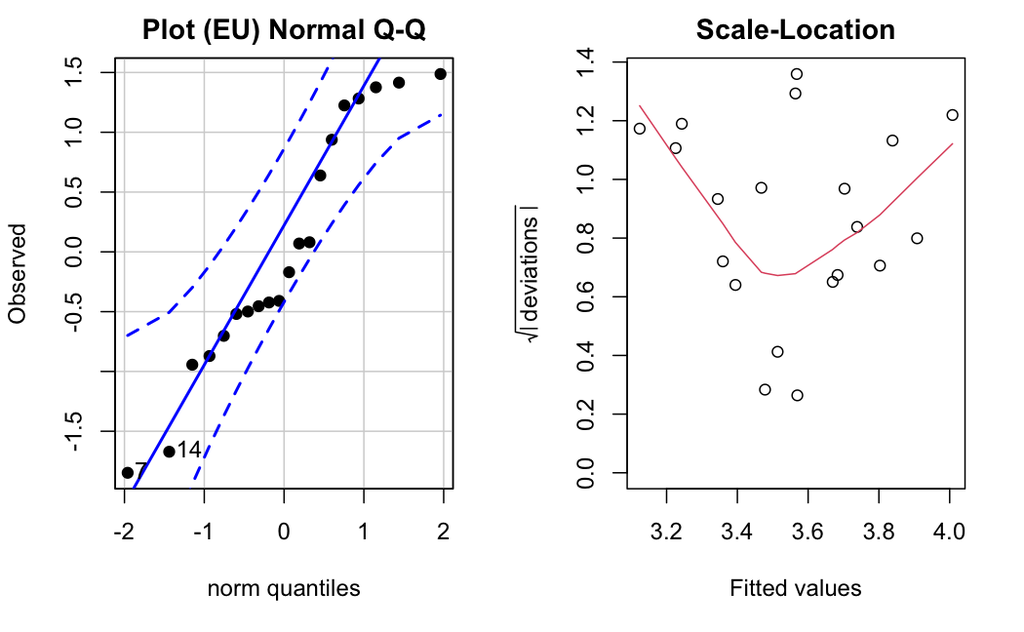

```r
# creating the model
beta_model <- lm(Beta ~ Species + Field, data = data_1)

# linearity and normality diagnostics
pls205_diagnostics(beta_model, EU = 'Field:Species')
```

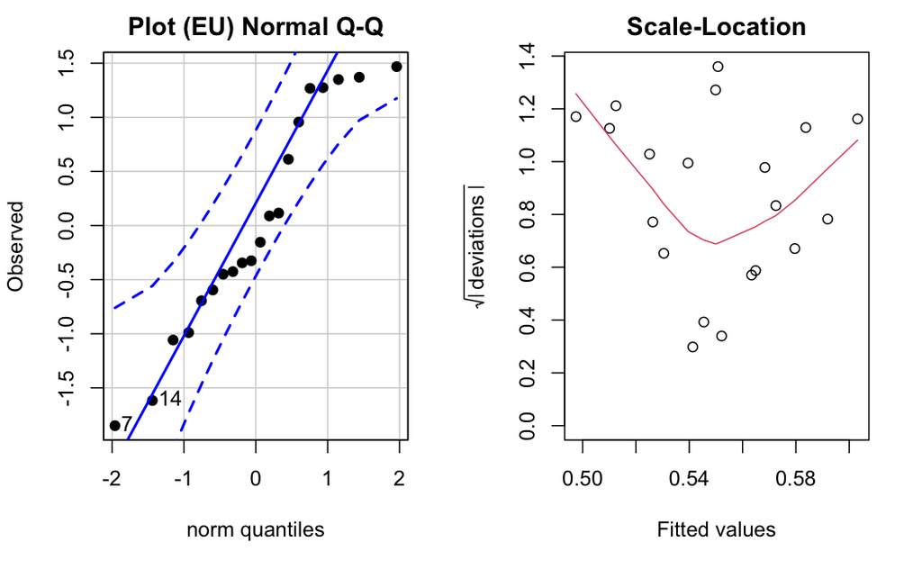

```r
# transforming the data with log10()
data_1$Betalog10 <- log10(data_1$Beta)
beta_log10 <- lm(Betalog10 ~ Species + Field, data=data_1)
pls205_diagnostics(beta_log10, EU = 'Field:Species')
```

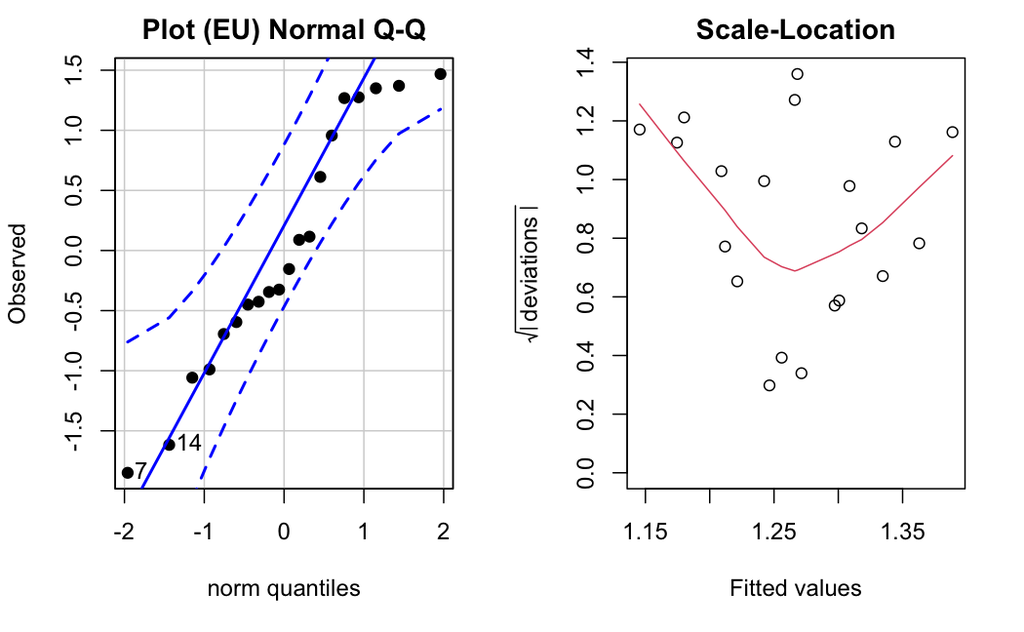

```r
# transforming the data with log()
data_1$Betalog <- log(data_1$Beta)
beta_log <- lm(Betalog ~ Species + Field, data=data_1)
pls205_diagnostics(beta_log, EU = 'Field:Species')
```

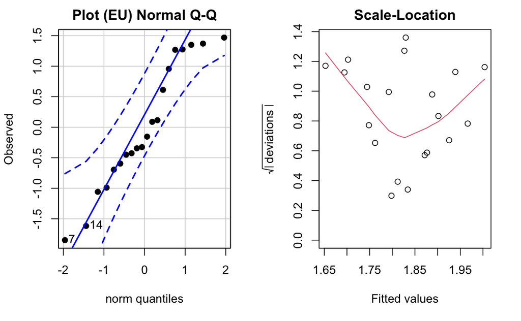

```r
# transforming the data with log2()
data_1$Betalog2 <- log2(data_1$Beta)
beta_log2 <- lm(Betalog2 ~ Species + Field, data=data_1)
pls205_diagnostics(beta_log2, EU = 'Field:Species')
```

> The EU plot seems to be reasonably linear. The points begin to trail off at the top and there is a “dip” in the middle, so a transformation may achieve a better fit. Log base 10, log base 2, and natural log tranformations provide the same marginal improvement in fit. The Scale-Location plot has a decent spread, but there is a “U” shape which indicates that there may be multiplicative interactions. All tranformations slightly flatten the line here. These transformations seem to be largely ineffective so I decided to proceed with the untransformed data.